# PASH Analysis

Seraphina Shi

# 1. Description of study population

# 2. Self-reported categorical fuel type

# 3. Cluster-based analyses

## PAH31 (no confounders)

```
## [1] " Result data: "
```

```
##                                        coef (sd)  coefficient    ci_lower
## AgeAccelerationResidual       0.1799    (0.5996)  0.179918947 -0.99528035
## AgeAccelerationResidualHannum -0.2175   (0.5319) -0.217507058 -1.26006387
## AgeAccelPheno                 0.0564    (0.4237)  0.056370845 -0.77408853
## DNAmAgeSkinBloodClockAdjAge   0.3281    (0.4025)  0.328123856 -0.46078372
## AgeAccelGrim                  0.9568 ***(0.2431)  0.956799062  0.48033687
## DNAmTLAdjAge                  -0.0096   (0.018 ) -0.009575373 -0.04481685
## IEAA                          0.1555    (0.6228)  0.155478006 -1.06521782
## EEAA                          -0.3147   (0.6558) -0.314671432 -1.59999433
##                                 ci_upper                 p_val sig_level
## AgeAccelerationResidual       1.35511825     0.764124357900777    > 0.05
## AgeAccelerationResidualHannum 0.82504975     0.682604352090157    > 0.05
## AgeAccelPheno                 0.88683022     0.894159326536994    > 0.05
## DNAmAgeSkinBloodClockAdjAge   1.11703143     0.414953989697454    > 0.05
## AgeAccelGrim                  1.43326126 0.0000828720085680468  <= 0.001
## DNAmTLAdjAge                  0.02566611     0.594347444217059    > 0.05
## IEAA                          1.37617383     0.802864249566636    > 0.05
## EEAA                          0.97065147     0.631337479666618    > 0.05
##                                         EAAs
## AgeAccelerationResidual          Horvath EAA
## AgeAccelerationResidualHannum     Hannum EAA
## AgeAccelPheno                   PhenoAge EAA
## DNAmAgeSkinBloodClockAdjAge   Skin&Blood EAA
## AgeAccelGrim                     GrimAge EAA
## DNAmTLAdjAge                          DNAmTL
## IEAA                                    IEAA
## EEAA                                    EEAA
```

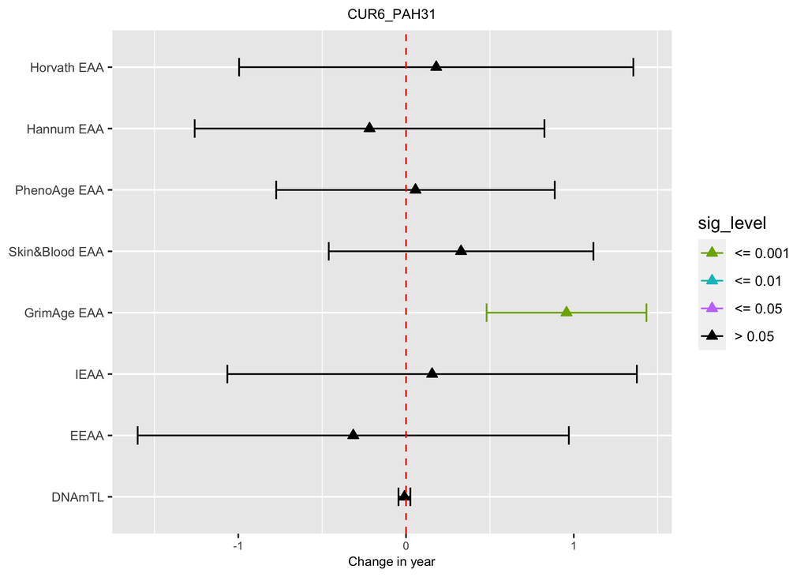

## PAH31 (MIX)

```
## [1] " Result data: "
```

[output not shown]

[figure not shown]

# 4. 5 methylchrysene (5MC)

## Summary the exposure estimates:

| **Characteristic** | **Overall**, N = 112<sup>1</sup> | **Smokeles**, N = 17<sup>1</sup> | **Smoky**, N = 87<sup>1</sup> | **Wood_and_or_Plant**, N = 8<sup>1</sup> |
| --- | --- | --- | --- | --- |
| cur_5mc | 7.81 (5.2, 9.7) | 2.59 (2.2, 4.0) | 9.46 (5.6, 10.1) | 7.40 (7.1, 7.4) |
| (Missing) | 3 | 2 | 1 | 0 |
| cum_5mc | 253.00 (157.7, 371.9) | 92.43 (82.6, 167.9) | 270.50 (179.9, 389.1) | 341.46 (228.8, 471.5) |
| (Missing) | 3 | 2 | 1 | 0 |
| bir_5mc | 4.83 (2.6, 8.2) | 2.10 (1.5, 4.4) | 4.83 (3.0, 8.2) | 8.02 (3.7, 8.8) |
| (Missing) | 3 | 2 | 1 | 0 |
| cur_5mc_measured | 5.64 (2.1, 8.7) | 1.82 (1.0, 2.3) | 7.02 (4.4, 9.7) | 4.64 (1.6, 6.8) |
| (Missing) | 67 | 10 | 55 | 2 |

<sup>1</sup> Median (IQR)

```
## [1] "Pearson pair-wise correlation:"
```

```
##                    cur_5mc   cum_5mc     bir_5mc cur_5mc_measured
## cur_5mc          1.0000000 0.7111247  0.66703068       0.12831853
## cum_5mc          0.7111247 1.0000000  0.81831424       0.18850136
## bir_5mc          0.6670307 0.8183142  1.00000000      -0.02596987
## cur_5mc_measured 0.1283185 0.1885014 -0.02596987       1.00000000
```

```
## [1] "Spearman pair-wise correlation:"
```

```
##                    cur_5mc   cum_5mc   bir_5mc cur_5mc_measured
## cur_5mc          1.0000000 0.6758096 0.6142748        0.4631276
## cum_5mc          0.6758096 1.0000000 0.7985763        0.3433940
## bir_5mc          0.6142748 0.7985763 1.0000000        0.3065790
## cur_5mc_measured 0.4631276 0.3433940 0.3065790        1.0000000
```

## Primary analyses

Effect of modeled current exposure to 5MC and EAA

### Generalized estimating equations (GEE)

#### No confounders

In the following section, we performed generalized estimating equations (GEE) with equation
$$\begin{aligned}
Y = & \beta_0 + \beta_1 *cur\_5mc + \epsilon
\end{aligned}$$
where $Y$ is one of the epigenetic age accelerations.

The estimations of $\beta_1$ with given $Y$ and current $5MC$ are shown below, which can be interpreted as “the mean of Y changes given a one-unit increase in current 5MC while holding other variables constant”.

```
## [1] " Result data: "
```

```
##                                        coef (sd)  coefficient    ci_lower
## AgeAccelerationResidual       0.0192    (0.1196)  0.019159838 -0.21529595
## AgeAccelerationResidualHannum -0.0416   (0.1012) -0.041572743 -0.23995405
## AgeAccelPheno                 0.0639    (0.1002)  0.063948683 -0.13251825
## DNAmAgeSkinBloodClockAdjAge   0.1048    (0.0752)  0.104833952 -0.04261433
## AgeAccelGrim                  0.1495 ** (0.0566)  0.149523037  0.03865547
## DNAmTLAdjAge                  -0.0038   (0.0035) -0.003814336 -0.01073470
## IEAA                          0.0016    (0.1278)  0.001582042 -0.24897278
## EEAA                          -0.0534   (0.1321) -0.053365322 -0.31226221
##                                  ci_upper               p_val sig_level
## AgeAccelerationResidual       0.253615625   0.872745484941928    > 0.05
## AgeAccelerationResidualHannum 0.156808565   0.681265269321088    > 0.05
## AgeAccelPheno                 0.260415616   0.523495170158012    > 0.05
## DNAmAgeSkinBloodClockAdjAge   0.252282229   0.163457636388872    > 0.05
## AgeAccelGrim                  0.260390608 0.00820827841291805   <= 0.01
## DNAmTLAdjAge                  0.003106025   0.280006515297229    > 0.05
## IEAA                          0.252136865   0.990125837758072    > 0.05
## EEAA                          0.205531563   0.686207920603063    > 0.05
##                                         EAAs
## AgeAccelerationResidual          Horvath EAA
## AgeAccelerationResidualHannum     Hannum EAA
## AgeAccelPheno                   PhenoAge EAA
## DNAmAgeSkinBloodClockAdjAge   Skin&Blood EAA
## AgeAccelGrim                     GrimAge EAA
## DNAmTLAdjAge                          DNAmTL
## IEAA                                    IEAA
## EEAA                                    EEAA
```

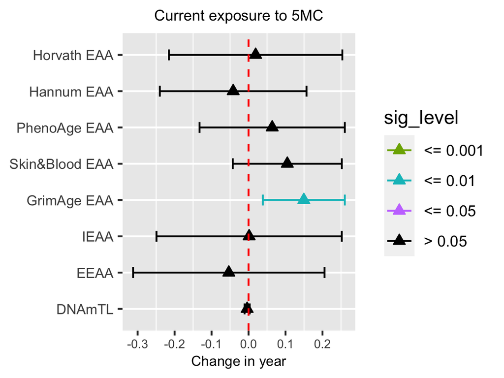

#### Mixed model

In the following section, we performed generalized estimating equations (GEE) with equation
$$\begin{aligned}
Y = & \beta_0 + \beta_1 *cur\_5mc\\
& + \beta_2 * county + \beta_3 * BMI + \beta_4 * ses + \beta_5 * edu + \epsilon
\end{aligned}$$
where $Y$ is one of the epigenetic age accelerations.

The estimations of $\beta_1$ with given $Y$ and current $5MC$ are shown below, which can be interpreted as “the mean of Y changes given a one-unit increase in current 5MC while holding other variables constant”.

```
## [1] " Result data: "
```

```
##                                        coef (sd)  coefficient    ci_lower
## AgeAccelerationResidual       0.0159    (0.1232)  0.015878690 -0.22561803
## AgeAccelerationResidualHannum -0.0512   (0.1039) -0.051171412 -0.25488423
## AgeAccelPheno                 0.0914    (0.0975)  0.091359722 -0.09973121
## DNAmAgeSkinBloodClockAdjAge   0.114     (0.0767)  0.114010349 -0.03626817
## AgeAccelGrim                  0.1677 ** (0.0513)  0.167727453  0.06708898
## DNAmTLAdjAge                  -0.0046   (0.0035) -0.004550865 -0.01136181
## IEAA                          0.0034    (0.1323)  0.003400224 -0.25585759
## EEAA                          -0.0682   (0.1386) -0.068201795 -0.33981776
##                                  ci_upper               p_val sig_level
## AgeAccelerationResidual       0.257375413   0.897458716697316    > 0.05
## AgeAccelerationResidualHannum 0.152541402   0.622479003468804    > 0.05
## AgeAccelPheno                 0.282450650   0.348723953264527    > 0.05
## DNAmAgeSkinBloodClockAdjAge   0.264288867   0.137021616586443    > 0.05
## AgeAccelGrim                  0.268365928 0.00108846725724532   <= 0.01
## DNAmTLAdjAge                  0.002260076   0.190326866190183    > 0.05
## IEAA                          0.262658041   0.979491967938557    > 0.05
## EEAA                          0.203414167   0.622614029655613    > 0.05
##                                         EAAs
## AgeAccelerationResidual          Horvath EAA
## AgeAccelerationResidualHannum     Hannum EAA
## AgeAccelPheno                   PhenoAge EAA
## DNAmAgeSkinBloodClockAdjAge   Skin&Blood EAA
## AgeAccelGrim                     GrimAge EAA
## DNAmTLAdjAge                          DNAmTL
## IEAA                                    IEAA
## EEAA                                    EEAA
```

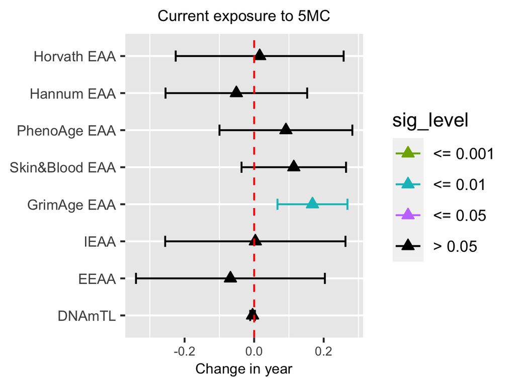

### Linear Regression (mix model)

In the following section, we performed linear regression with equation
$$\begin{aligned}
Y = & \beta_0 + \beta_1 *cur\_5mc\\
& + \beta_2 * county + \beta_3 * BMI + \beta_4 * ses + \beta_5 * edu + \epsilon
\end{aligned}$$
where $Y$ is one of the epigenetic age accelerations.

The estimations of $\beta_1$ with given $Y$ and $5MC$ are shown below, which can be interpreted as “the mean of Y changes given a one-unit increase in current 5MC while holding other variables constant”.

#### Including all visits

```
## [1] " Result data: "
```

```
##                                        coef (sd)  coefficient    ci_lower
## AgeAccelerationResidual       0.0207    (0.1049)  0.020733670 -0.18496178
## AgeAccelerationResidualHannum -0.0419   (0.0913) -0.041887057 -0.22076438
## AgeAccelPheno                 0.1005    (0.0905)  0.100522348 -0.07676839
## DNAmAgeSkinBloodClockAdjAge   0.1101    (0.0783)  0.110087986 -0.04343307
## AgeAccelGrim                  0.1859 ** (0.0581)  0.185902269  0.07207875
## DNAmTLAdjAge                  -0.003    (0.004 ) -0.003046936 -0.01092097
## IEAA                          0.0105    (0.0961)  0.010475037 -0.17787726
## EEAA                          -0.0454   (0.1152) -0.045442978 -0.27130842
##                                  ci_upper               p_val sig_level
## AgeAccelerationResidual       0.226429117   0.843750902791681    > 0.05
## AgeAccelerationResidualHannum 0.136990268   0.647164122161031    > 0.05
## AgeAccelPheno                 0.277813088   0.268860884675762    > 0.05
## DNAmAgeSkinBloodClockAdjAge   0.263609043   0.162693464549318    > 0.05
## AgeAccelGrim                  0.299725793 0.00178954419368209   <= 0.01
## DNAmTLAdjAge                  0.004827099   0.449808711450213    > 0.05
## IEAA                          0.198827332   0.913398260459483    > 0.05
## EEAA                          0.180422468    0.69409202484541    > 0.05
##                                         EAAs
## AgeAccelerationResidual          Horvath EAA
## AgeAccelerationResidualHannum     Hannum EAA
## AgeAccelPheno                   PhenoAge EAA
## DNAmAgeSkinBloodClockAdjAge   Skin&Blood EAA
## AgeAccelGrim                     GrimAge EAA
## DNAmTLAdjAge                          DNAmTL
## IEAA                                    IEAA
## EEAA                                    EEAA
```

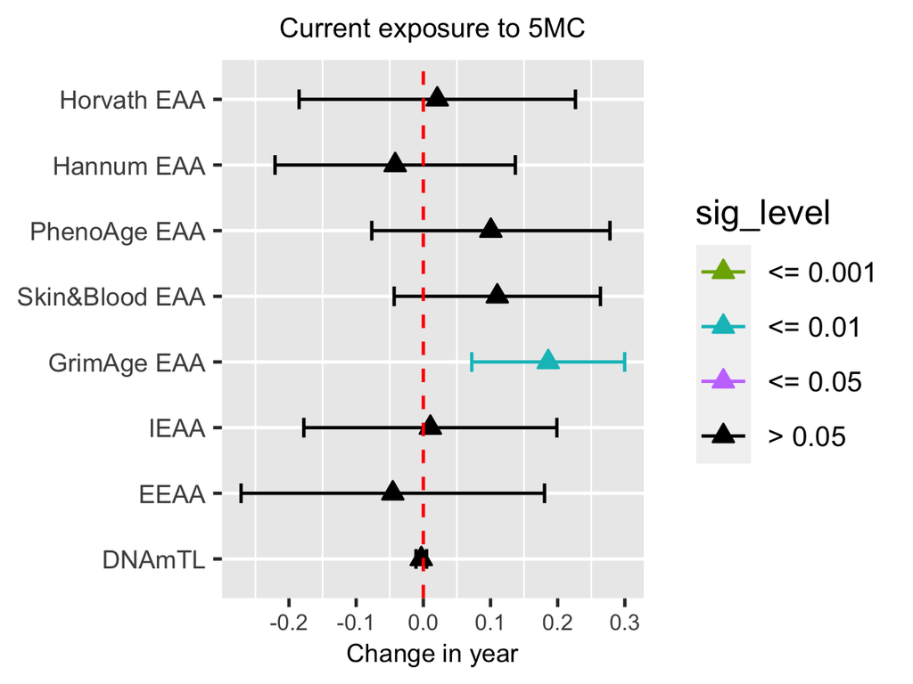

#### Only including one of the two visits

Including all of the single visits and the 1st visit for these 23 subjects who have been visited twice.

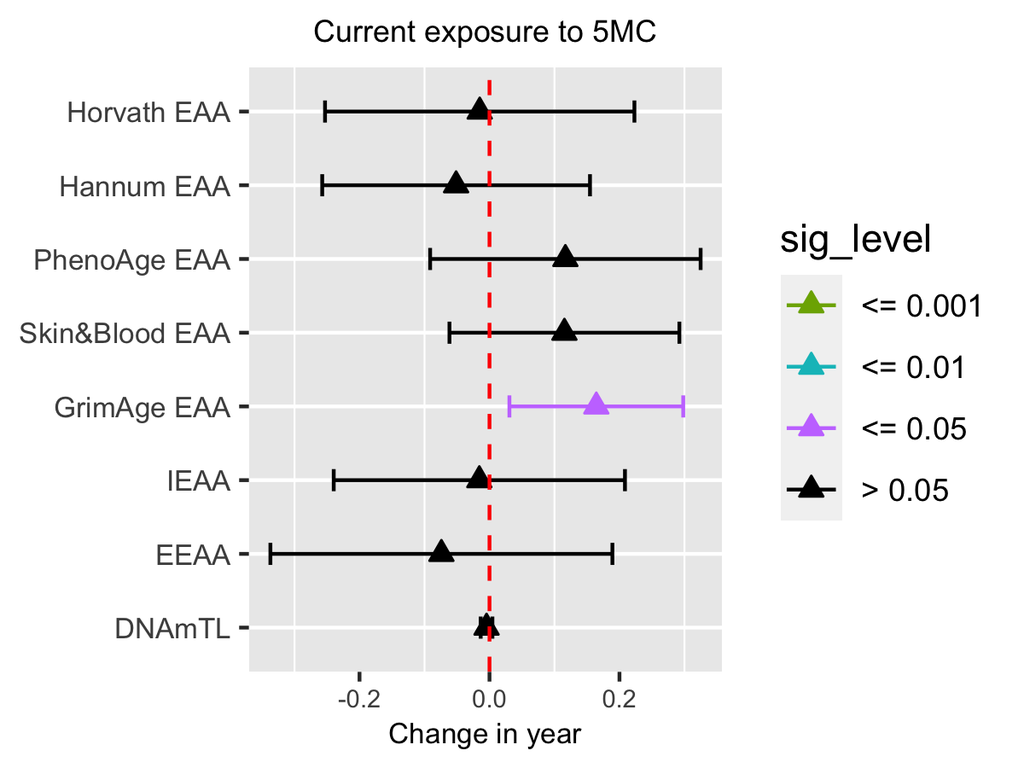

Including all of the single visits and the 2nd visit for these 23 subjects who have been visited twice.

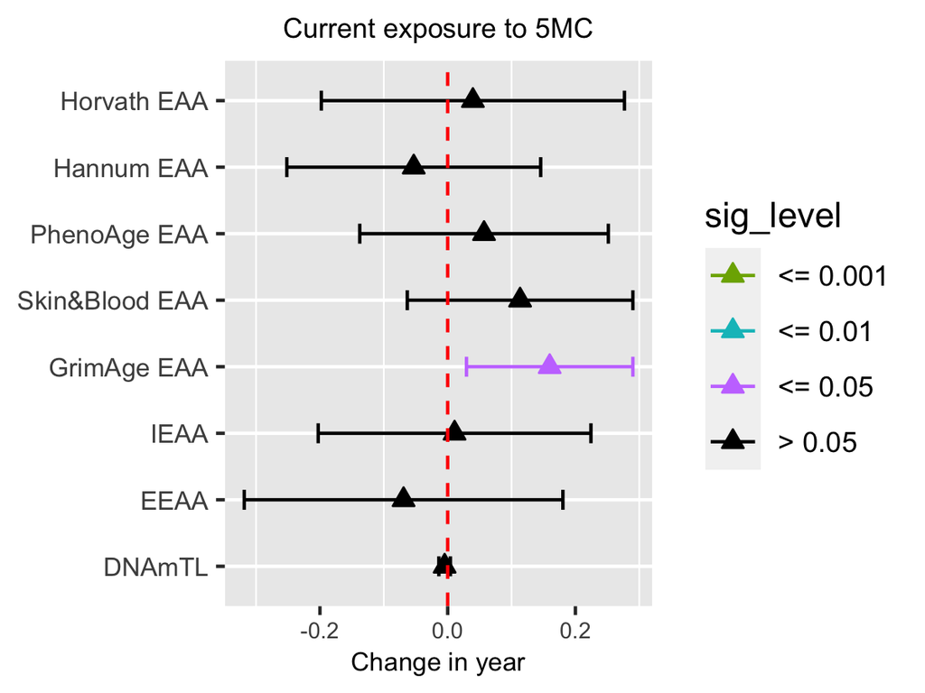

## Secondary analyses

### i. Effect of modeled cumulative exposure to 5MC and EAA

#### Generalized estimating equations (GEE)

In the following section, we performed generalized estimating equations (GEE) with equation
$$\begin{aligned}
Y = & \beta_0 + \beta_1 *cum\_5mc\\
& + \beta_2 * county + \beta_3 * BMI + \beta_4 * ses + \beta_5 * edu + \epsilon
\end{aligned}$$
where $Y$ is one of the epigenetic age accelerations.

The estimations of $\beta_1$ with given $Y$ and cumulative $5MC$ are shown below, which can be interpreted as “the mean of Y changes given a one-unit increase in cumulative 5MC while holding other variables constant”.

```
## [1] " Result data: "
```

```
##                                        coef (sd)   coefficient      ci_lower
## AgeAccelerationResidual       0.0003    (0.0036)  0.0002634684 -0.0067212672
## AgeAccelerationResidualHannum 0.0035    (0.003 )  0.0034941270 -0.0024591729
## AgeAccelPheno                 0.0045    (0.0031)  0.0044586214 -0.0015505393
## DNAmAgeSkinBloodClockAdjAge   0.0025    (0.0027)  0.0025381617 -0.0027202036
## AgeAccelGrim                  0.006  ***(0.0017)  0.0059797751  0.0025667569
## DNAmTLAdjAge                  -0.0001   (0.0001) -0.0001321556 -0.0004090747
## IEAA                          -0.0019   (0.0034) -0.0019359695 -0.0085095111
## EEAA                          0.0055    (0.0039)  0.0054840443 -0.0021583732
##                                   ci_upper                p_val sig_level
## AgeAccelerationResidual       0.0072482039    0.941064206728588    > 0.05
## AgeAccelerationResidualHannum 0.0094474269    0.249992106478145    > 0.05
## AgeAccelPheno                 0.0104677820    0.145873502832328    > 0.05
## DNAmAgeSkinBloodClockAdjAge   0.0077965270    0.344111409021191    > 0.05
## AgeAccelGrim                  0.0093927932 0.000594708988064241  <= 0.001
## DNAmTLAdjAge                  0.0001447635    0.349591731827019    > 0.05
## IEAA                          0.0046375721    0.563778458819213    > 0.05
## EEAA                          0.0131264618    0.159588653069498    > 0.05
##                                         EAAs
## AgeAccelerationResidual          Horvath EAA
## AgeAccelerationResidualHannum     Hannum EAA
## AgeAccelPheno                   PhenoAge EAA
## DNAmAgeSkinBloodClockAdjAge   Skin&Blood EAA
## AgeAccelGrim                     GrimAge EAA
## DNAmTLAdjAge                          DNAmTL
## IEAA                                    IEAA
## EEAA                                    EEAA
```

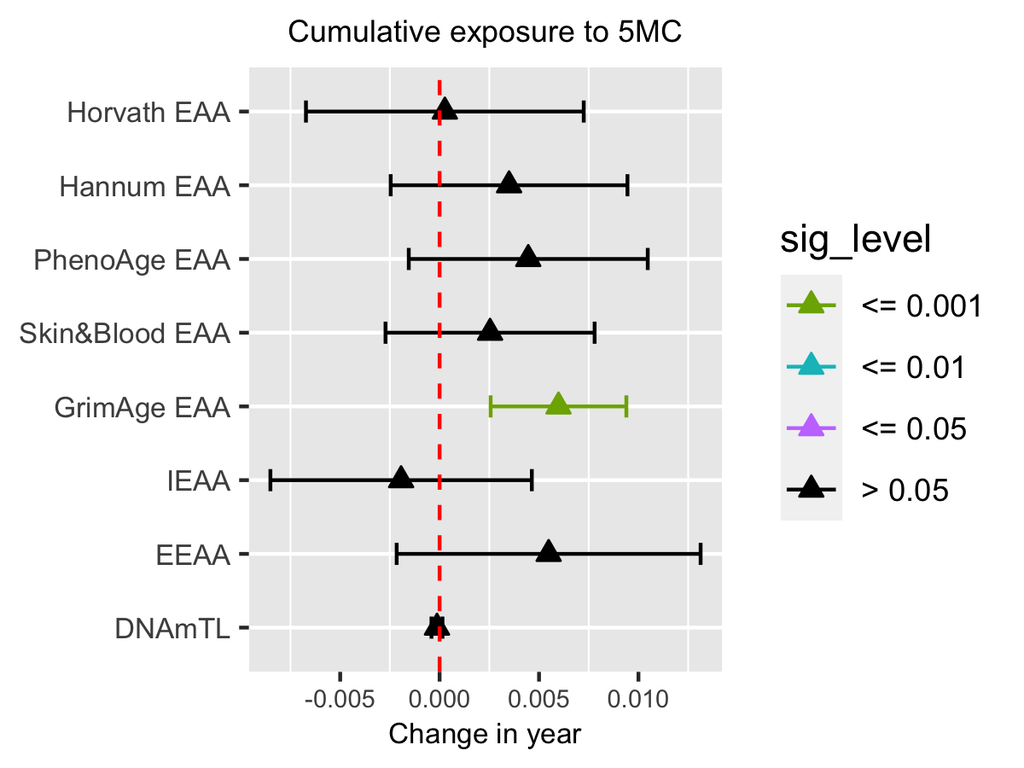

#### Linear Regression (mix model)

In the following section, we performed linear regression with equation
$$\begin{aligned}
Y = & \beta_0 + \beta_1 *cum\_5mc\\
& + \beta_2 * county + \beta_3 * BMI + \beta_4 * ses + \beta_5 * edu + \epsilon
\end{aligned}$$
where $Y$ is one of the epigenetic age accelerations.

The estimations of $\beta_1$ with given $Y$ and $5MC$ are shown below, which can be interpreted as “the mean of Y changes given a one-unit increase in cumulative 5MC while holding other variables constant”.

##### Including all visits

```
## [1] " Result data: "
```

```
##                                        coef (sd)    coefficient      ci_lower
## AgeAccelerationResidual       0.001     (0.0033)  0.00103650748 -0.0053403710
## AgeAccelerationResidualHannum 0.0038    (0.0028)  0.00379397142 -0.0017129311
## AgeAccelPheno                 0.0046    (0.0028)  0.00456487266 -0.0008975400
## DNAmAgeSkinBloodClockAdjAge   0.0028    (0.0024)  0.00276052438 -0.0020149908
## AgeAccelGrim                  0.0064 ***(0.0018)  0.00637247485  0.0028794399
## DNAmTLAdjAge                  -0.0001   (0.0001) -0.00008623203 -0.0003305153
## IEAA                          -0.001    (0.003 ) -0.00103128270 -0.0068692888
## EEAA                          0.0058    (0.0035)  0.00581872108 -0.0011055319
##                                   ci_upper               p_val sig_level
## AgeAccelerationResidual       0.0074133860   0.750648090319113    > 0.05
## AgeAccelerationResidualHannum 0.0093008739   0.179679063556041    > 0.05
## AgeAccelPheno                 0.0100272853   0.104289937607713    > 0.05
## DNAmAgeSkinBloodClockAdjAge   0.0075360396   0.259680451090652    > 0.05
## AgeAccelGrim                  0.0098655098 0.00052036941541486  <= 0.001
## DNAmTLAdjAge                  0.0001580512    0.49047028014843    > 0.05
## IEAA                          0.0048067234    0.72982851067324    > 0.05
## EEAA                          0.0127429741   0.102398656798027    > 0.05
##                                         EAAs
## AgeAccelerationResidual          Horvath EAA
## AgeAccelerationResidualHannum     Hannum EAA
## AgeAccelPheno                   PhenoAge EAA
## DNAmAgeSkinBloodClockAdjAge   Skin&Blood EAA
## AgeAccelGrim                     GrimAge EAA
## DNAmTLAdjAge                          DNAmTL
## IEAA                                    IEAA
## EEAA                                    EEAA
```

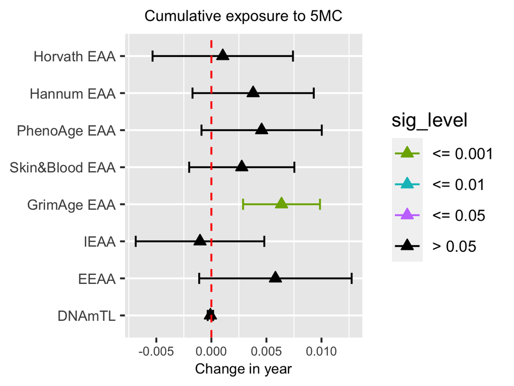

### ii. Effect of modeled birth home/childhood exposure to 5MC

#### Generalized estimating equations (GEE)

In the following section, we performed generalized estimating equations (GEE) with equation
$$\begin{aligned}
Y = & \beta_0 + \beta_1 *birth\_5mc\\
& + \beta_2 * county + \beta_3 * BMI + \beta_4 * ses + \beta_5 * edu + \epsilon
\end{aligned}$$
where $Y$ is one of the epigenetic age accelerations.

The estimations of $\beta_1$ with given $Y$ and birth home/childhood $5MC$ are shown below, which can be interpreted as “the mean of Y changes given a one-unit increase in birth home/childhood 5MC while holding other variables constant”.

```
## [1] " Result data: "
```

```
##                                        coef (sd)  coefficient    ci_lower
## AgeAccelerationResidual       0.0025    (0.1756)  0.002549647 -0.34172123
## AgeAccelerationResidualHannum 0.2141    (0.1569)  0.214124879 -0.09340150
## AgeAccelPheno                 0.3281 *  (0.155 )  0.328090148  0.02422719
## DNAmAgeSkinBloodClockAdjAge   0.1847    (0.1274)  0.184739910 -0.06495355
## AgeAccelGrim                  0.3165 ** (0.0963)  0.316489482  0.12768544
## DNAmTLAdjAge                  -0.0034   (0.007 ) -0.003382397 -0.01719450
## IEAA                          -0.1728   (0.1645) -0.172753745 -0.49523718
## EEAA                          0.3134    (0.2014)  0.313411448 -0.08136084
##                                ci_upper               p_val sig_level
## AgeAccelerationResidual       0.3468205   0.988418609834732    > 0.05
## AgeAccelerationResidualHannum 0.5216513   0.172343774292717    > 0.05
## AgeAccelPheno                 0.6319531  0.0343216724056407   <= 0.05
## DNAmAgeSkinBloodClockAdjAge   0.4344334   0.147019764983751    > 0.05
## AgeAccelGrim                  0.5052935 0.00101794428051305   <= 0.01
## DNAmTLAdjAge                  0.0104297   0.631243324757604    > 0.05
## IEAA                          0.1497297   0.293732747964983    > 0.05
## EEAA                          0.7081837   0.119695588251105    > 0.05
##                                         EAAs
## AgeAccelerationResidual          Horvath EAA
## AgeAccelerationResidualHannum     Hannum EAA
## AgeAccelPheno                   PhenoAge EAA
## DNAmAgeSkinBloodClockAdjAge   Skin&Blood EAA
## AgeAccelGrim                     GrimAge EAA
## DNAmTLAdjAge                          DNAmTL
## IEAA                                    IEAA
## EEAA                                    EEAA
```

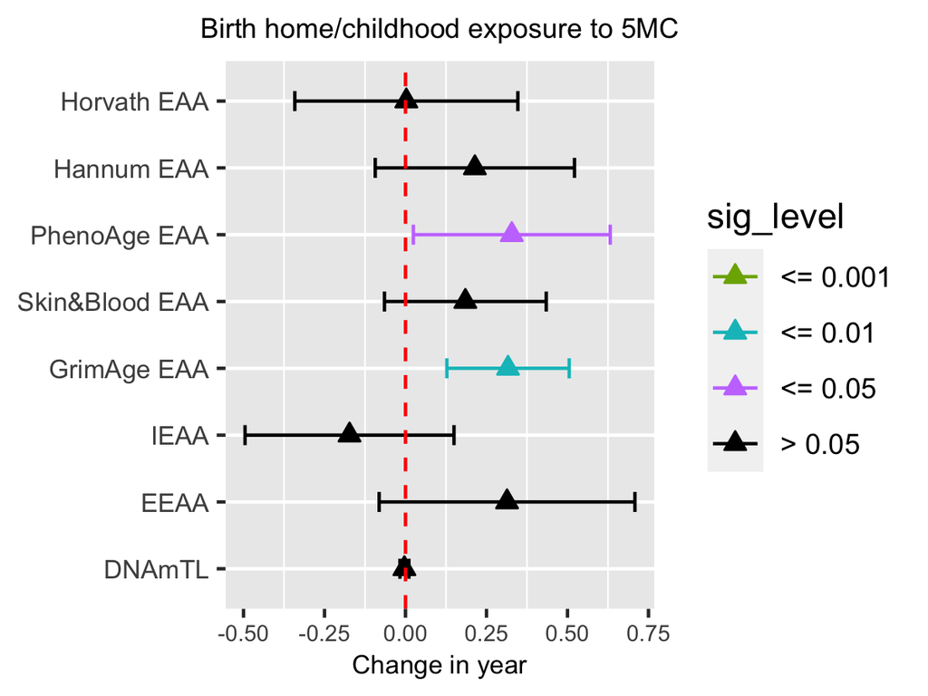

#### Linear Regression (mix model)

In the following section, we performed linear regression with equation
$$\begin{aligned}
Y = & \beta_0 + \beta_1 *birth\_5mc\\
& + \beta_2 * county + \beta_3 * BMI + \beta_4 * ses + \beta_5 * edu + \epsilon
\end{aligned}$$
where $Y$ is one of the epigenetic age accelerations.

The estimations of $\beta_1$ with given $Y$ and birth home/childhood $5MC$ are shown below, which can be interpreted as “the mean of Y changes given a one-unit increase in birth home/childhood 5MC while holding other variables constant”.

##### Including all visits

```
## [1] " Result data: "
```

```
##                                        coef (sd)  coefficient    ci_lower
## AgeAccelerationResidual       0.0098    (0.1637)  0.009782899 -0.31111335
## AgeAccelerationResidualHannum 0.2069    (0.1411)  0.206939438 -0.06965063
## AgeAccelPheno                 0.3239 *  (0.1385)  0.323913401  0.05249473
## DNAmAgeSkinBloodClockAdjAge   0.1972    (0.1218)  0.197237400 -0.04153770
## AgeAccelGrim                  0.3165 ***(0.0898)  0.316458874  0.14050344
## DNAmTLAdjAge                  -0.0011   (0.0063) -0.001136672 -0.01344886
## IEAA                          -0.1425   (0.1493) -0.142531806 -0.43513042
## EEAA                          0.3057    (0.1775)  0.305657343 -0.04223925
##                                 ci_upper                p_val sig_level
## AgeAccelerationResidual       0.33067915    0.952460860656415    > 0.05
## AgeAccelerationResidualHannum 0.48352950    0.145382879129861    > 0.05
## AgeAccelPheno                 0.59533207    0.021136962042337   <= 0.05
## DNAmAgeSkinBloodClockAdjAge   0.43601249    0.108303371907858    > 0.05
## AgeAccelGrim                  0.49241430 0.000618237725277051  <= 0.001
## DNAmTLAdjAge                  0.01117552    0.856740648508633    > 0.05
## IEAA                          0.15006680    0.341791023208332    > 0.05
## EEAA                          0.65355394   0.0878748036123461    > 0.05
##                                         EAAs
## AgeAccelerationResidual          Horvath EAA
## AgeAccelerationResidualHannum     Hannum EAA
## AgeAccelPheno                   PhenoAge EAA
## DNAmAgeSkinBloodClockAdjAge   Skin&Blood EAA
## AgeAccelGrim                     GrimAge EAA
## DNAmTLAdjAge                          DNAmTL
## IEAA                                    IEAA
## EEAA                                    EEAA
```

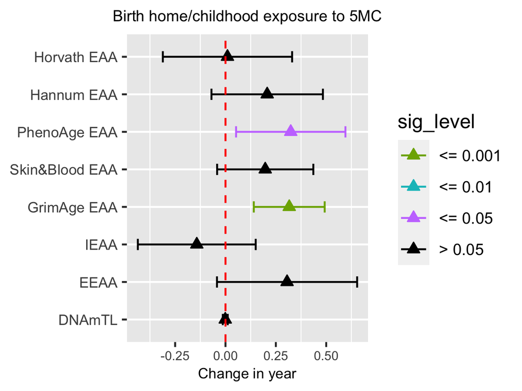

### iii. Effect of measured current exposure to 5MC

#### Generalized estimating equations (GEE)

In the following section, we performed generalized estimating equations (GEE) with equation
$$\begin{aligned}
Y = & \beta_0 + \beta_1 *cur\_measured\_5mc\\
& + \beta_2 * county + \beta_3 * BMI + \beta_4 * ses + \beta_5 * edu + \epsilon
\end{aligned}$$
where $Y$ is one of the epigenetic age accelerations.

The estimations of $\beta_1$ with given $Y$ and measured current exposure to $5MC$ are shown below, which can be interpreted as “the mean of Y changes given a one-unit increase in measured current exposure to 5MC while holding other variables constant”.

```
## [1] " Result data: "
```

```
##                                        coef (sd)   coefficient      ci_lower
## AgeAccelerationResidual       -0.0161   (0.0116) -0.0160930304 -0.0388463043
## AgeAccelerationResidualHannum 0.0121    (0.0094)  0.0121388435 -0.0062336364
## AgeAccelPheno                 -0.0124   (0.0106) -0.0124219804 -0.0331607762
## DNAmAgeSkinBloodClockAdjAge   0.0052    (0.0104)  0.0052270379 -0.0150652135
## AgeAccelGrim                  0.0096    (0.0071)  0.0096229772 -0.0042772676
## DNAmTLAdjAge                  -0.0003   (0.0003) -0.0002604479 -0.0009026825
## IEAA                          -0.0222** (0.0082) -0.0222372500 -0.0383592726
## EEAA                          0.0154    (0.0112)  0.0153629305 -0.0064989105
##                                    ci_upper               p_val sig_level
## AgeAccelerationResidual        0.0066602435   0.165662347120224    > 0.05
## AgeAccelerationResidualHannum  0.0305113235   0.195324515612494    > 0.05
## AgeAccelPheno                  0.0083168154   0.240400138182616    > 0.05
## DNAmAgeSkinBloodClockAdjAge    0.0255192892   0.613648578514261    > 0.05
## AgeAccelGrim                   0.0235232220   0.174817716392433    > 0.05
## DNAmTLAdjAge                   0.0003817866   0.426702704133811    > 0.05
## IEAA                          -0.0061152274 0.00686246950979708   <= 0.01
## EEAA                           0.0372247716   0.168404952099984    > 0.05
##                                         EAAs
## AgeAccelerationResidual          Horvath EAA
## AgeAccelerationResidualHannum     Hannum EAA
## AgeAccelPheno                   PhenoAge EAA
## DNAmAgeSkinBloodClockAdjAge   Skin&Blood EAA
## AgeAccelGrim                     GrimAge EAA
## DNAmTLAdjAge                          DNAmTL
## IEAA                                    IEAA
## EEAA                                    EEAA
```

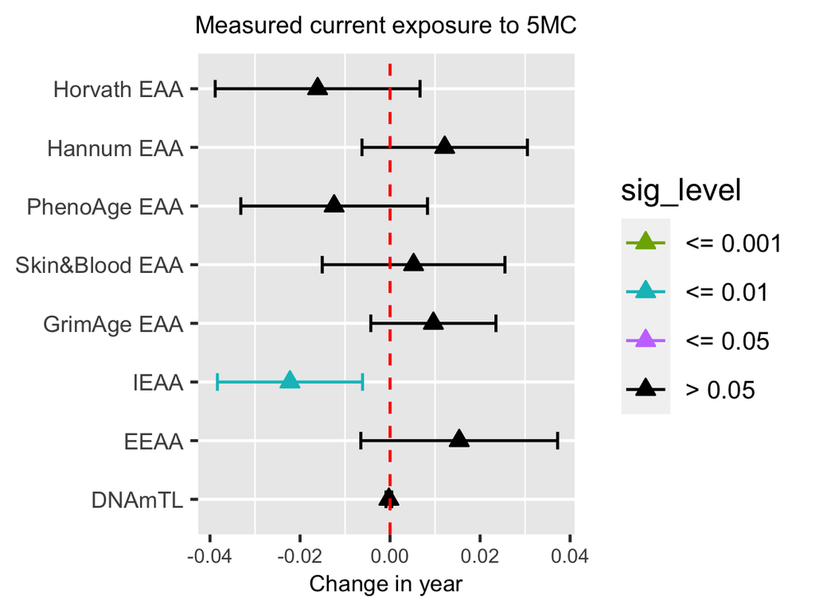

#### Linear Regression (mix model)

The estimations of $\beta_1$ with given $Y$ and measured current exposure to 5MC$ are shown below, which can be interpreted as “the mean of Y changes given a one-unit increase in measured current exposure to 5MC while holding other variables constant”.

##### Including all visits

```
## [1] " Result data: "
```

```
##                                        coef (sd)  coefficient     ci_lower
## AgeAccelerationResidual       -0.016    (0.0195) -0.016022707 -0.054216478
## AgeAccelerationResidualHannum 0.0122    (0.0163)  0.012170057 -0.019861322
## AgeAccelPheno                 -0.0122   (0.0173) -0.012155809 -0.046147335
## DNAmAgeSkinBloodClockAdjAge   0.0053    (0.0165)  0.005310579 -0.026971127
## AgeAccelGrim                  0.0097    (0.0117)  0.009659968 -0.013302592
## DNAmTLAdjAge                  -0.0003   (0.0008) -0.000258984 -0.001783975
## IEAA                          -0.0222   (0.0167) -0.022160762 -0.054881608
## EEAA                          0.0154    (0.0205)  0.015395379 -0.024871166
##                                  ci_upper             p_val sig_level
## AgeAccelerationResidual       0.022171064 0.415583167756025    > 0.05
## AgeAccelerationResidualHannum 0.044201436   0.4606084575144    > 0.05
## AgeAccelPheno                 0.021835716 0.487217454828268    > 0.05
## DNAmAgeSkinBloodClockAdjAge   0.037592285  0.74872318878492    > 0.05
## AgeAccelGrim                  0.032622528 0.414291462572805    > 0.05
## DNAmTLAdjAge                  0.001266007 0.740895770814662    > 0.05
## IEAA                          0.010560085 0.191532466581911    > 0.05
## EEAA                          0.055661923 0.457805164498975    > 0.05
##                                         EAAs
## AgeAccelerationResidual          Horvath EAA
## AgeAccelerationResidualHannum     Hannum EAA
## AgeAccelPheno                   PhenoAge EAA
## DNAmAgeSkinBloodClockAdjAge   Skin&Blood EAA
## AgeAccelGrim                     GrimAge EAA
## DNAmTLAdjAge                          DNAmTL
## IEAA                                    IEAA
## EEAA                                    EEAA
```

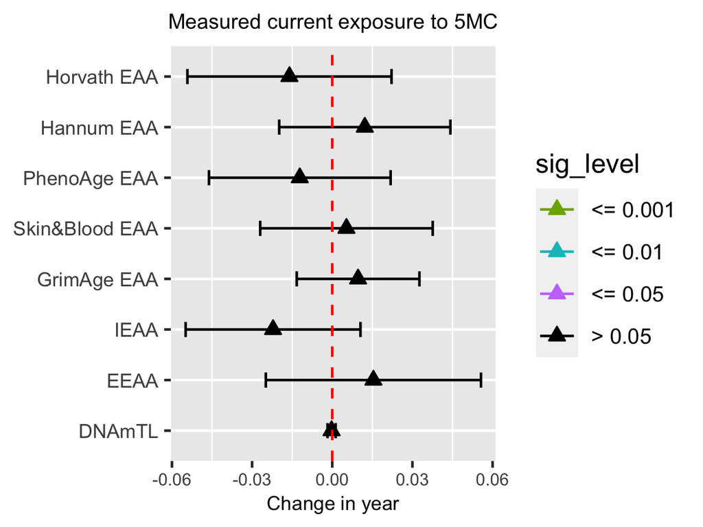

# 5. Additional secondary analyses